# An overview of AnthropMMD

# 3 Alternative: analysis using bootstrapped samples

Starting with `{AnthropMMD}` version 4.0.0, a bootstrap method introduced by Daniel Fidalgo and co-workers (Fidalgo, Hubbe, and Wesolowski 2021; Fidalgo, Wesolowski, and Hubbe 2022) is now available. Please note that:

- this method is only available when the input data is a “raw binary dataset”, as described earlier in this vignette (see Section 2.1.1);
- this method requires longer computations than the standard MMD, so that it is not available through the graphical user interface.

Let’s start again from the dataset `toyMMD`. The first step is to perform the resampling and the MMD computations using the separate function `mmd_boot()`. Fidalgo, Wesolowski, and Hubbe (2022) suggest a value of `B = 100` bootstrap experiments, it is thus the default value for the corresponding argument in this function. Below, for this simple example, we will use a value of `B = 50`. Be careful: the computation time (in the current implementation) will grow quite fast for high values of `B`.

Note that `mmd_boot()` takes care itself of the trait selection. All arguments usually submitted to `select_traits()` can also be passed to `mmd_boot()`; see example below.

```r
## Load the example data once again:
data(toyMMD)
## Compute MMD among bootstrapped samples:
set.seed(2023) # set seed for reproducibility
resboot <- mmd_boot(
    data = toyMMD,
    B = 50, # number of bootstrap samples
    angular = "Anscombe",
    strategy = "keepFisher", # strategy for trait selection
    k = 10 # minimal number of observations required per trait
)
```

Now you can simply `plot()` the result of your computations, and set various parameters to customize your plot:

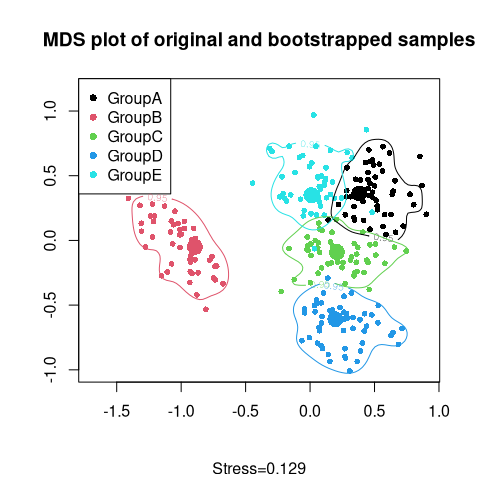

```r
## MDS plot for bootstrapped samples:
plot(
    x = resboot,
    method = "interval", # algorithm used for MDS computation
    level = 0.95, # confidence level for the contour lines
    gof = TRUE # display goodness of fit statistic
)
```

This plot displays the contour lines of a 2D kernel density estimation, as in Figure 3 from Fidalgo, Wesolowski, and Hubbe (2022).

# References

Bertsatos, Andreas, and Maria-Eleni Chovalopoulou. 2016. “Technical Note: A GNU Octave Function for Smith’s Mean Measure of Divergence.” *Bioarchaeology of the Near East* 10: 69–73.

de Souza, Peter, and Philip Houghton. 1977. “The Mean Measure of Divergence and the Use of Non-Metric Data in the Estimation of Biological Distances.” *Journal of Archaeological Science* 4 (2): 163–69. https://doi.org/10.1016/0305-4403(77)90063-2.

Donlon, D. A. 2000. “The Value of Infracranial Nonmetric Variation in Studies of Modern Homo Sapiens: An Australian Focus.” *American Journal of Physical Anthropology* 113 (3): 349–68. https://doi.org/10.1002/1096-8644(200011)113:3<349::AID-AJPA6>3.0.CO;2-2.

Fidalgo, Daniel, Mark Hubbe, and Veronica Wesolowski. 2021. “Population History of Brazilian South and Southeast Shellmound Builders Inferred Through Dental Morphology.” *American Journal of Physical Anthropology* 176 (2): 192–207. https://doi.org/10.1002/ajpa.24342.

Fidalgo, Daniel, Veronica Wesolowski, and Mark Hubbe. 2022. “Biological Affinities of Brazilian Pre-Colonial Coastal Communities Explored Through Bootstrapped Biodistances of Dental Non-Metric Traits.” *Journal of Archaeological Science* 138: 105545. https://doi.org/10.1016/j.jas.2022.105545.

Harris, E. F., and T. Sjøvold. 2004. “Calculations of Smith’s Mean Measure of Divergence for Intergroup Comparisons Using Nonmetric Data.” *Dental Anthropology* 17: 83–93.

Santos, Frédéric. 2018. “AnthropMMD: An R package with a graphical user interface for the mean measure of divergence.” *American Journal of Physical Anthropology* 165 (1): 200–205. https://doi.org/10.1002/ajpa.23336.

Sjøvold, T. 1973. “Occurrence of Minor Non-Metrical Variants in the Skeleton and Their Quantitative Treatment for Population Comparisons.” *Homo* 24: 204–33.

———. 1977. “Non-metrical divergence between skeletal populations: the theoretical foundation and biological importance of C.A.B. Smith’s mean measure of divergence.” *Ossa* 1: 1–133.